# Data science with H2O

A classification problem: Telco Customer Churn

A. Ghorbani

August 27, 2016

A data science example using H2O (h2o.ai) to investigate a classification problem, namely customer churn.

# Introduction

H2O is a open-source machine learning software for big-data. It is produced in 2011 by the start-up H2O.ai. The performance of H2O allows to do a lot of data science analysis possible through fit hundreds of models, fast prediction of large data and a lot other interesting thing that some of them we will be see in this document.

The problem under study is classification of a telecom company customer into whether they would stay as customer or leave the company. Many companies are interested to know when, why, which customer they are going to lose. Acquiring this information they can take action accordingly.

I chose churn analysis here just as an example, any other classification problem can be done the well.

The purpose of this note is to show how this analysis can be done using h2o.

I am going to cover the following analysis:

- prediction of customer churn probability using gradient boosting machine (GBM),
- parameter tuning using Bayesian optimization,
- interpretation of the model:
  - specifying the co-variables that have importance for the analysis,
  - specifying the most important co-variables that is responsible for churn probability of each individual customer,
  - constructing a single decision tree (for interpretation of the black box GBM model),
  - (partial) dependence of churn probabilities on each co-variables.

# Load the required packages

The following packages are necessary for this analysis.

```r
#=========================================
# TODO: remove unnecessary packages
#=========================================
library(rpart)
library(rattle)
library(rpart.plot)
library(RColorBrewer)
library(partykit)
library(caret)
library(party)
library(rBayesianOptimization)
require(readr)
require(data.table)
require(reshape2)
library(pROC)
require(ggplot2)

require(h2o)
```

# Init H2O (connect to a running H2O cluster)

We need to download h2o package, if we hadn’t installed before. At the time of writing this text the latest version was 3.11.0.3596 and I downloaded from [here](http://s3.amazonaws.com/h2o-release/h2o/master/3596/index.html). After downloading we need to unzip it.

I usually prefer to run h2o from command line. For more details on how to start h2o from command line see [here](http://docs.h2o.ai/h2o/latest-stable/h2o-docs/starting-h2o.html#from-the-command-line).

```bash
> java -jar h2o.jar -nthreads 2 -ice_root ./tmp -port 54321 -name AwesomeCloud
```

Additionally you need to install h2o `R` API package in `R`.

```r
install.packages("path_to_h2o_dir/h2o-3.11.0.3596/R/h2o_3.11.0.3596.tar.gz", repos=NULL, type = "source")
```

Finally use `h2o.init()` to connect the h2o cluster (in our case with only one node).

```r
# Connect to h2o cluster
h2o.init(port = 54321, startH2O = FALSE)
```

```
##  Connection successful!
##
## R is connected to the H2O cluster:
##     H2O cluster uptime:         12 days 17 hours
##     H2O cluster version:        3.11.0.3596
##     H2O cluster version age:    23 days
##     H2O cluster name:           AwesomeCloud
##     H2O cluster total nodes:    1
##     H2O cluster total memory:   3.36 GB
##     H2O cluster total cores:    4
##     H2O cluster allowed cores:  2
##     H2O cluster healthy:        TRUE
##     H2O Connection ip:          localhost
##     H2O Connection port:        54321
##     H2O Connection proxy:       NA
##     R Version:                  R version 3.2.3 (2015-12-10)
```

```r
h2o.removeAll()
```

```
## [1] 0
```

# Load the data into h2o

For this example, here, we use the data from http://www.dataminingconsultant.com/data/churn.txt. The description of the columns can be found [here](http://www.sgi.com/tech/mlc/db/churn.names).

```r
data_frame <-
  h2o.importFile(
    path              = "http://www.dataminingconsultant.com/data/churn.txt",
    sep               = ",",
    destination_frame = "data_frame")
```

Let’s have a look at the data:

| State | Account Length | Area Code | Phone | Int’l Plan | VMail Plan | VMail Message | Day Mins | Day Calls | Day Charge | Eve Mins | Eve Calls | Eve Charge | Night Mins | Night Calls | Night Charge | Intl Mins | Intl Calls | Intl Charge | CustServ Calls | Churn? |
| --- | --- | --- | --- | --- | --- | --- | --- | --- | --- | --- | --- | --- | --- | --- | --- | --- | --- | --- | --- | --- |
| KS | 128 | 415 | 382-4657 | no | yes | 25 | 265.1 | 110 | 45.07 | 197.4 | 99 | 16.78 | 244.7 | 91 | 11.01 | 10.0 | 3 | 2.70 | 1 | False. |
| OH | 107 | 415 | 371-7191 | no | yes | 26 | 161.6 | 123 | 27.47 | 195.5 | 103 | 16.62 | 254.4 | 103 | 11.45 | 13.7 | 3 | 3.70 | 1 | False. |
| NJ | 137 | 415 | 358-1921 | no | no | 0 | 243.4 | 114 | 41.38 | 121.2 | 110 | 10.30 | 162.6 | 104 | 7.32 | 12.2 | 5 | 3.29 | 0 | False. |
| OH | 84 | 408 | 375-9999 | yes | no | 0 | 299.4 | 71 | 50.90 | 61.9 | 88 | 5.26 | 196.9 | 89 | 8.86 | 6.6 | 7 | 1.78 | 2 | False. |
| OK | 75 | 415 | 330-6626 | yes | no | 0 | 166.7 | 113 | 28.34 | 148.3 | 122 | 12.61 | 186.9 | 121 | 8.41 | 10.1 | 3 | 2.73 | 3 | False. |

We can use `h2o.describe` to obtain some basic statistics about the variables, like mean, min, max, number of missing values, etc.

```r
#kable(h2o.summary(data_frame, exact_quantiles = TRUE),  digits=2)

kable(h2o.describe(data_frame), digits = 2)
```

| Label | Type | Missing | Zeros | PosInf | NegInf | Min | Max | Mean | Sigma | Cardinality |
| --- | --- | --- | --- | --- | --- | --- | --- | --- | --- | --- |
| State | enum | 0 | 52 | 0 | 0 | 0 | 50 | NA | NA | 51 |
| Account Length | int | 0 | 0 | 0 | 0 | 1 | 243 | 101.064806480648 | 39.8221059285957 | NA |
| Area Code | int | 0 | 0 | 0 | 0 | 408 | 510 | 437.182418241824 | 42.3712904856066 | NA |
| Phone | string | 0 | 0 | 0 | 0 | NaN | NaN | NA | NA | NA |
| Int’l Plan | enum | 0 | 3010 | 0 | 0 | 0 | 1 | 0.0969096909690969 | 0.295879145484415 | 2 |
| VMail Plan | enum | 0 | 2411 | 0 | 0 | 0 | 1 | 0.276627662766277 | 0.447397870380064 | 2 |
| VMail Message | int | 0 | 2411 | 0 | 0 | 0 | 51 | 8.09900990099009 | 13.6883653720386 | NA |
| Day Mins | real | 0 | 2 | 0 | 0 | 0 | 350.8 | 179.775097509751 | 54.4673892023715 | NA |
| Day Calls | int | 0 | 2 | 0 | 0 | 0 | 165 | 100.435643564356 | 20.0690842073009 | NA |
| Day Charge | real | 0 | 2 | 0 | 0 | 0 | 59.64 | 30.5623072307231 | 9.2594345539305 | NA |
| Eve Mins | real | 0 | 1 | 0 | 0 | 0 | 363.7 | 200.980348034804 | 50.713844425812 | NA |
| Eve Calls | int | 0 | 1 | 0 | 0 | 0 | 170 | 100.114311431143 | 19.9226252939431 | NA |
| Eve Charge | real | 0 | 1 | 0 | 0 | 0 | 30.91 | 17.0835403540353 | 4.31066764311035 | NA |
| Night Mins | real | 0 | 0 | 0 | 0 | 23.2 | 395 | 200.87203720372 | 50.5738470136584 | NA |
| Night Calls | int | 0 | 0 | 0 | 0 | 33 | 175 | 100.107710771077 | 19.5686093460585 | NA |
| Night Charge | real | 0 | 0 | 0 | 0 | 1.04 | 17.77 | 9.03932493249326 | 2.27587283766003 | NA |
| Intl Mins | real | 0 | 18 | 0 | 0 | 0 | 20 | 10.2372937293729 | 2.79183954840842 | NA |
| Intl Calls | int | 0 | 18 | 0 | 0 | 0 | 20 | 4.47944794479448 | 2.4612142705461 | NA |
| Intl Charge | real | 0 | 18 | 0 | 0 | 0 | 5.4 | 2.76458145814581 | 0.753772612663045 | NA |
| CustServ Calls | int | 0 | 697 | 0 | 0 | 0 | 9 | 1.56285628562856 | 1.31549104486648 | NA |
| Churn? | enum | 0 | 2850 | 0 | 0 | 0 | 1 | 0.144914491449145 | 0.352067423624126 | 2 |

NOTE: The function `kable()` is used just to have a nice table in the output.

The column `Churn?` specifies whether the customer has left the plan or not. For exact meaning of other columns see [here](http://www.sgi.com/tech/mlc/db/churn.names).

In order to build and assess the model we are going to split the data into *training*, *validation* and *testing* data set. I assume that the analysis here is applied to a large data set. It is not true in this example, though, since we have only 3333 number of rows, which is not that big. In such case it is better to split the data set into only training and testing. And for model selection and hyper-parameter tuning using cross-validation.

Since, I assume the example here will be used for a very large data set, otherwise why somebody wants to use H2O ;), the data set is split into training, validation and testing with ratio of %50, %25 and %25, respectively.

```r
split_df  <-
  h2o.splitFrame(
    data               = data_frame,
    ratios             = c(0.5,0.25),
    destination_frames = c("train_frame", "valid_frame", "test_frame"),
    seed               = 2016)

train_frame <- split_df[[1]]
valid_frame <- split_df[[2]]
test_frame  <- split_df[[3]]
```

# Building model

First the target variable, which is `Churn?` and the co-variables (the rest of the other variables) are defined.

```r
y <- "Churn?"
x <- setdiff(names(data_frame),  c(y))
```

## Bayesian Optimization

Each algorithm has number of hyper-parameters to be set, like in case of GBM number of trees or learning rate, etc. As always one of the important question is which values to choose for the hyper-parameters. There are different ways to find the optimal values for hyper-parameters, like grid search, random search or other general optimization algorithm.

H2O supports grid search and random search. Grid search is kind of brute force and random search is too crude. I wished H2O guys implemented Bayesian optimization. But no worries. There are bunch of Bayesian optimization algorithms in `R`. On the other hand the heavy lifting part, which is function evaluation (i.e. building the models), will be carried out by H2O. In the following it shall be shown how we can use `rBaysianOptimisation` package for finding the optimal hyper-parameters.

The function `h2o_bayes` is defined as a wrapper for `h2o.gbm` function, which builds and evaluates a GBM model. All the parameters that needs to be optimized are defined as an argument. In order to score each model here *validation* data set is used. However, for small data set in this example usually it is better to use cross-validation (instead of validation data set) to decrease variation in the model score.

```r
#============================
# Define the wrapper function
#============================
h2o_bayes <- function(
  max_depth, learn_rate, sample_rate,
  col_sample_rate, balance_classes){
  bal.cl <- as.logical(balance_classes)
  gbm <- h2o.gbm(
    x                   = x,
    y                   = y,
    training_frame      = train_frame,
    validation_frame    = valid_frame,
    #nfolds              = 3,
    ntrees              = 900,
    max_depth           = max_depth,
    learn_rate          = learn_rate,
    sample_rate         = sample_rate,
    col_sample_rate     = col_sample_rate,
    score_tree_interval = 5,
    stopping_rounds     = 2,
    stopping_metric     = "logloss",
    stopping_tolerance  = 0.005,
    balance_classes     = bal.cl)

  score <- h2o.auc(gbm, valid = T)
  list(Score = score,
       Pred  = 0)
}

#============================
# Find optimal values for the
# parameters in the given range.
#============================
OPT_Res <- BayesianOptimization(
  h2o_bayes,
  bounds = list(
    max_depth   = c(2L, 8L),
    learn_rate  = c(1e-4, 0.2),
    sample_rate = c(0.4, 1),
    col_sample_rate = c(0.4, 1),
    balance_classes = c(0L, 1L)),
  init_points = 3,  n_iter = 3,
  acq = "ucb", kappa = 2.576, eps = 0.0,
  verbose = FALSE)
```

```
##
##  Best Parameters Found:
## Round = 3    max_depth = 2.0000  learn_rate = 0.0398 sample_rate = 0.8901    col_sample_rate = 0.9453    balance_classes = 0.0000    Value = 0.9008
```

## Building the model using optimal parameters

After searching for the best hyper-parameters using Bayesian optimization algorithm, we use the values found above to train a GBM model.

```r
gbm <- h2o.gbm(
  x                   = x,
  y                   = y,
  training_frame      = train_frame,
  validation_frame    = valid_frame,
  ntrees              = 900,
  max_depth           = OPT_Res$Best_Par["max_depth"],
  learn_rate          = OPT_Res$Best_Par["learn_rate"],
  sample_rate         = OPT_Res$Best_Par["sample_rate"],
  col_sample_rate     = OPT_Res$Best_Par["col_sample_rate"],
  balance_classes     = as.logical(OPT_Res$Best_Par["balance_classes"]),
  score_tree_interval = 5,
  stopping_rounds     = 2,
  stopping_metric     = "logloss",
  stopping_tolerance  = 0.005,
  model_id         = "my_awesome_GBM")
```

## Train a model using only important co-variables

In the previous try to train a GBM model all the columns in the data have been used. Many times removing irrelevant data from the training data will improves the results for various reason. Even if it doesn’t improve the result, it will reduce the amount of resources needed for calculation, e.g. CPU time and memory.

Hence, a model is trained with only important variables that can be obtained from previous calculation.

```r
var.imp <- h2o.varimp(gbm)[h2o.varimp(gbm)$scaled_importance > 0.01, "variable"]
# The value of 0.01 is arbitrary, you might want to use other values.

setdiff(x, var.imp)

gbm_varImp <- h2o.gbm(
  x                   = var.imp,
  y                   = y,
  training_frame      = train_frame,
  validation_frame    = valid_frame,
  ntrees              = 900,
  max_depth           = OPT_Res$Best_Par["max_depth"],
  learn_rate          = OPT_Res$Best_Par["learn_rate"],
  sample_rate         = OPT_Res$Best_Par["sample_rate"],
  col_sample_rate     = OPT_Res$Best_Par["col_sample_rate"],
  balance_classes     = as.logical(OPT_Res$Best_Par["balance_classes"]),
  score_tree_interval = 5,
  stopping_rounds     = 2,
  stopping_metric     = "logloss",
  stopping_tolerance  = 0.005,
  model_id         = "my_awesome_GBM_varImp")
```

## Compare the two model

The two models are compared in the plots below, in terms of rmse and auc. It is clearly visible that if we use all the co-variables no significant improvement is achieved.

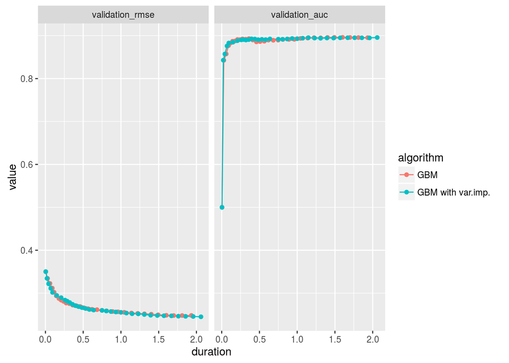

```r
shist <- gbm@model$scoring_history[, c("duration", "validation_rmse", "validation_auc")]
shist$algorithm <- "GBM"
scoring_history <- shist

shist <- gbm_varImp@model$scoring_history[, c("duration", "validation_rmse", "validation_auc")]
shist$algorithm <- "GBM with var.imp."
scoring_history <- rbind(scoring_history,shist)

scoring_history$duration <- as.numeric(
  gsub("sec", "", scoring_history$duration))

scoring_history <- melt(scoring_history, id = c("duration", "algorithm"))

ggplot(data = scoring_history,
       aes(x     = duration,
           y     = value,
           color = algorithm,
           group = algorithm)) +
  geom_line() + geom_point() +
  facet_grid(. ~ variable, scales = "free",shrink = TRUE,space = "free")
```

Choose the best model based on `AUC` measure (you could choose `mse`, `logloss` or other measures).

```r
AUC_gbm        <- h2o.performance(gbm, valid = T)@metrics$AUC
AUC_gbm_varImp <- h2o.performance(gbm_varImp, valid = T)@metrics$AUC
if(AUC_gbm > AUC_gbm_varImp){
  bestModel <- gbm
}else{
  bestModel <- gbm_varImp
}
cat("The best model is '", bestModel@model_id,
    "' with AUC of ", max(AUC_gbm, AUC_gbm_varImp),
    " vs ",  min(AUC_gbm, AUC_gbm_varImp), "\n" )
```

```
## The best model is ' my_awesome_GBM_varImp ' with AUC of  0.8956946  vs  0.8953587
```

# Model Assessment

Now we use the test data to measure the performance of the model:

```r
bestPerf <- h2o.performance(bestModel, test_frame)

perfDF <- melt(as.data.frame(bestPerf@metrics$thresholds_and_metric_scores),
           id = "threshold")
```

Performance of the model on the test data:

```r
kable(
  as.data.frame(
    bestPerf@metrics[c("MSE", "RMSE", "AUC", "r2", "logloss", "Gini", "mean_per_class_error")]),
  digits = 3)
```

| MSE | RMSE | AUC | r2 | logloss | Gini | mean_per_class_error |
| --- | --- | --- | --- | --- | --- | --- |
| 0.067 | 0.258 | 0.907 | 0.483 | 0.238 | 0.815 | 0.155 |

As you know the prediction of the model is a probability of a customer is going to leave or not.

Lets have a look at the prediction distribution, for each class:

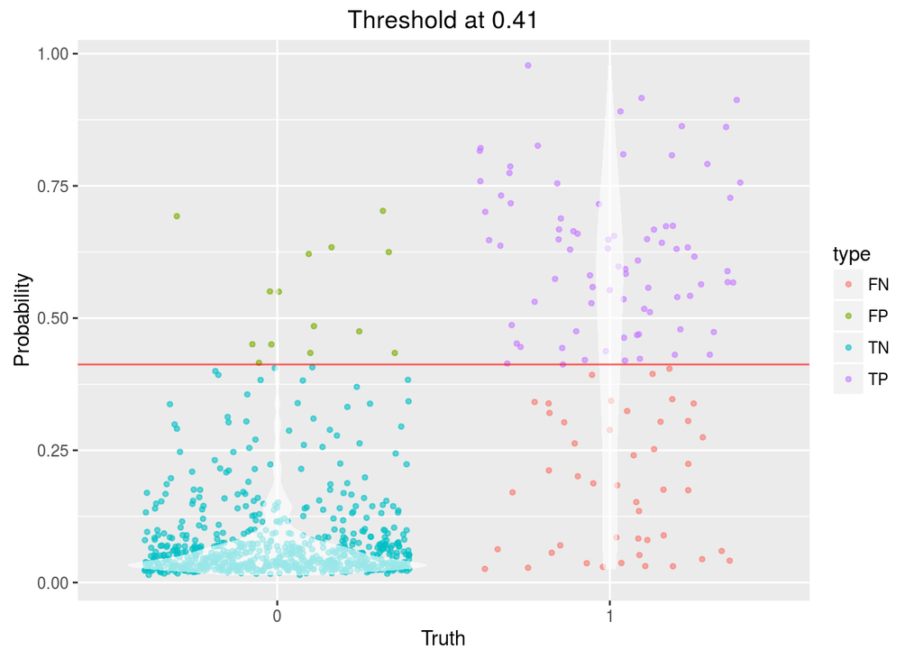

We would like to have all data points be either in top right (True Positive (TP)) or bottom left (True Negative (TN)).

So, which customer is going to leave? If the prediction value is more than 0.5? well it depends on our criteria. Here are some of the criteria and the maximum value we can get depending on which criteria we choose:

```r
kable(bestPerf@metrics$max_criteria_and_metric_scores, digits = 3)
```

| metric | threshold | value | idx |
| --- | --- | --- | --- |
| max f1 | 0.303 | 0.739 | 115 |
| max f2 | 0.171 | 0.782 | 155 |
| max f0point5 | 0.412 | 0.795 | 88 |
| max accuracy | 0.412 | 0.927 | 88 |
| max precision | 0.978 | 1.000 | 0 |
| max recall | 0.026 | 1.000 | 376 |
| max specificity | 0.978 | 1.000 | 0 |
| max absolute_mcc | 0.412 | 0.694 | 88 |
| max min_per_class_accuracy | 0.135 | 0.854 | 182 |
| max mean_per_class_accuracy | 0.171 | 0.873 | 155 |

and here are the plots of few of them.

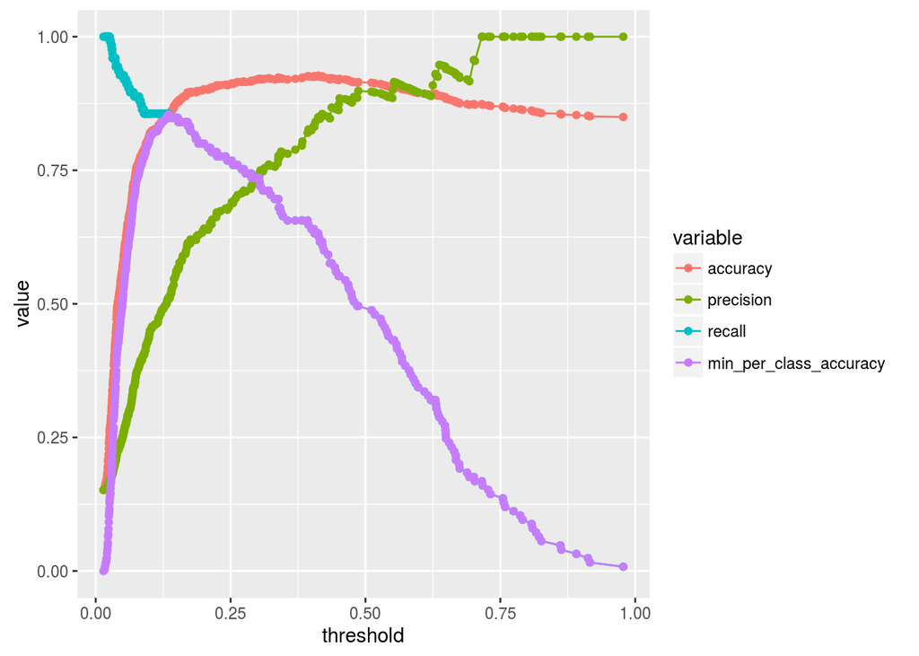

```r
scores_to_plot <- c("accuracy", "precision", "recall", "min_per_class_accuracy")

ggplot(data = perfDF[perfDF$variable %in% scores_to_plot, ],
       aes(x     = threshold,
           y     = value,
           color = variable,
           group = variable)) +
  geom_line() + geom_point()
```

```r
#kable(bestPerf@metrics, digits = 3)
```

If we know the actual costs (in the business) of false positives and false negatives (or benefits of true positives) we can have better decision on which criteria to choose.

# Interpretation of the Model

Up to now we built the model and evaluated. The algorithm that we used above was GBM, which is a black box model. That means it only gives us prediction on which customers are going to leave, i.e. the probabilities. The interpretation of the model, like *why*s, is not that straight.

However, we would like to have some more insights and be able to answer questions like what are the reason that customers are leaving or a customer might to leave.

## Variable Importance

In many situations not all the co-variables are not equally important. Some variable are more important that the others. Using variable importance we can focus more on important variables.

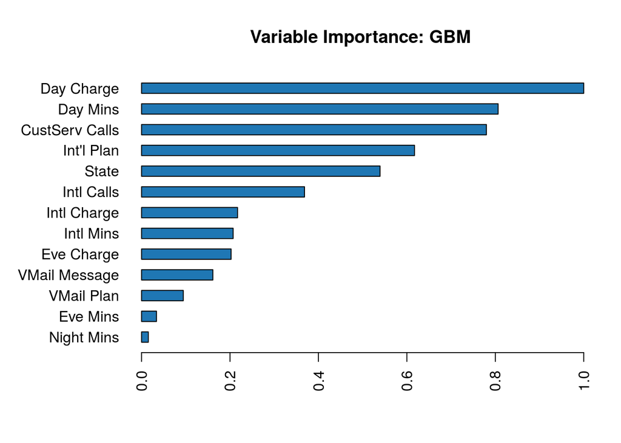

```r
h2o.varimp_plot(bestModel)
```

## Variable Importance per Customer

The above mentioned variables were measured based on the whole training data set and is only valid on average. However the importance of each variable might be different for each individual customer.

We can use the trained model to approximate the variable importance based on each individual customer.

In this approach a prediction is done on the data set. And then we leave a column out and will do the prediction again and measure the difference in probabilities. The difference in probabilities can indicate the importance of that variable for each customer.

This have a little bit of calculation in `R` side, like calculating differences and ranking each row based on these differences. Hence, in order to speed up thing I have implemented a C++ code (`get_high_rank_values.cpp`) which also needed to be *sourced*. Using `Rcpp` package one can simply use C++ code in `R` script.

```r
require(Rcpp)
Rcpp::sourceCpp("get_high_rank_values.cpp")
source("https://raw.githubusercontent.com/a-ghorbani/notebooks/master/H2O/examples/churn/rowVarImp.R")

df <- rowVarImp.h2o(model=bestModel, cols=var.imp, data_frame=test_frame, n=3)
```

Here only first 3 importance variable for each customer are calculated. The first 3 columns show the differences by not including the variable. The next 3 columns show their values and the last 3 columns the variables names.

Knowing these information the business unit can take measures based on each individual customer.

```r
kable(
  head(df),
  digits=3
)
```

| imp_VI1 | imp_VI2 | imp_VI3 | value_VI1 | value_VI2 | value_VI3 | colName_VI1 | colName_VI2 | colName_VI3 |
| --- | --- | --- | --- | --- | --- | --- | --- | --- |
| 0 | 0 | 0 | no | 12.7 | no | VMail Plan | Intl Mins | Int’l Plan |
| -0.00425742181056014 | -0.00274618378277128 | -0.00121645399011531 | 163.4 | 13.89 | 5 | Eve Mins | Eve Charge | Intl Calls |
| -0.00968143602711302 | 0 | 0 | 6 | 13.1 | no | Intl Calls | Intl Mins | Int’l Plan |
| -0.00186710746987492 | 0 | 0 | FL | 155.1 | 26.37 | State | Day Mins | Day Charge |
| -0.00892828607733831 | -0.00409639941646311 | 0 | 6 | CO | no | Intl Calls | State | Int’l Plan |
| -0.00029391790293809 | 0 | 0 | 5 | 124.3 | 21.13 | Intl Calls | Day Mins | Day Charge |

## Partial Dependence Plots

In previous section we talked about importance of each variable, but we didn’t answer the question what to do.  
However, it is very important to know if we change value of variable what will be the impact on the outcome.

For each value for can answer that by the so called partial dependence plots. In the following the partial dependence plots are shown for the 5 top important variables (using `partialDependencePlot.R`).

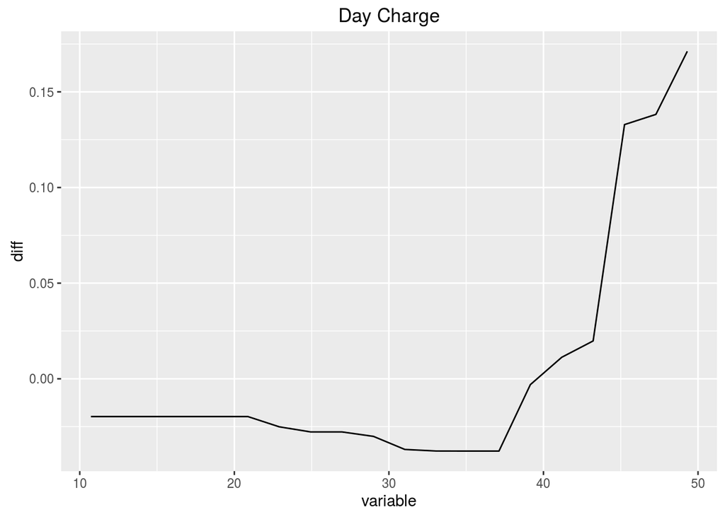

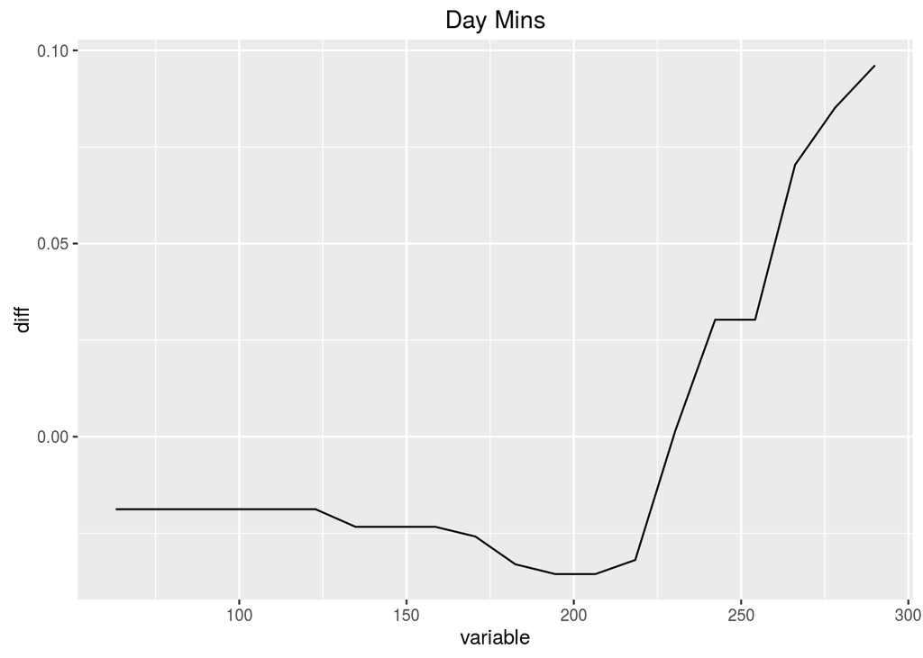

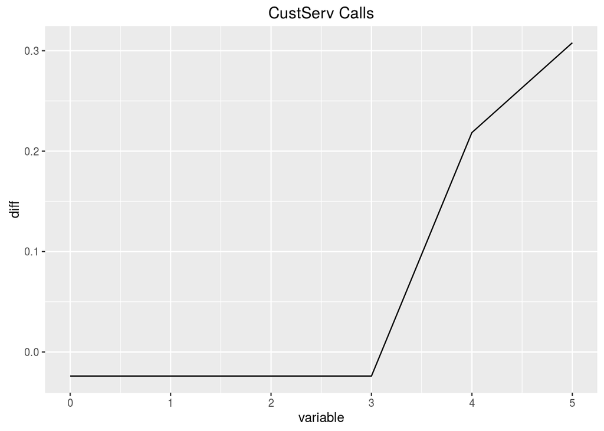

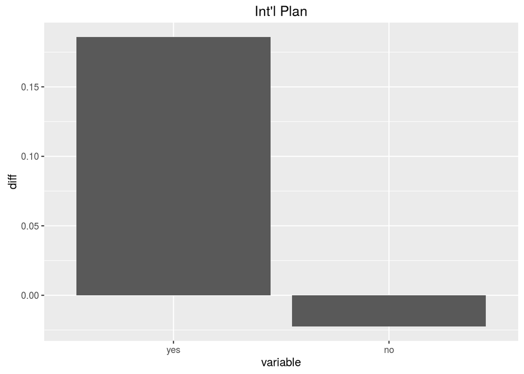

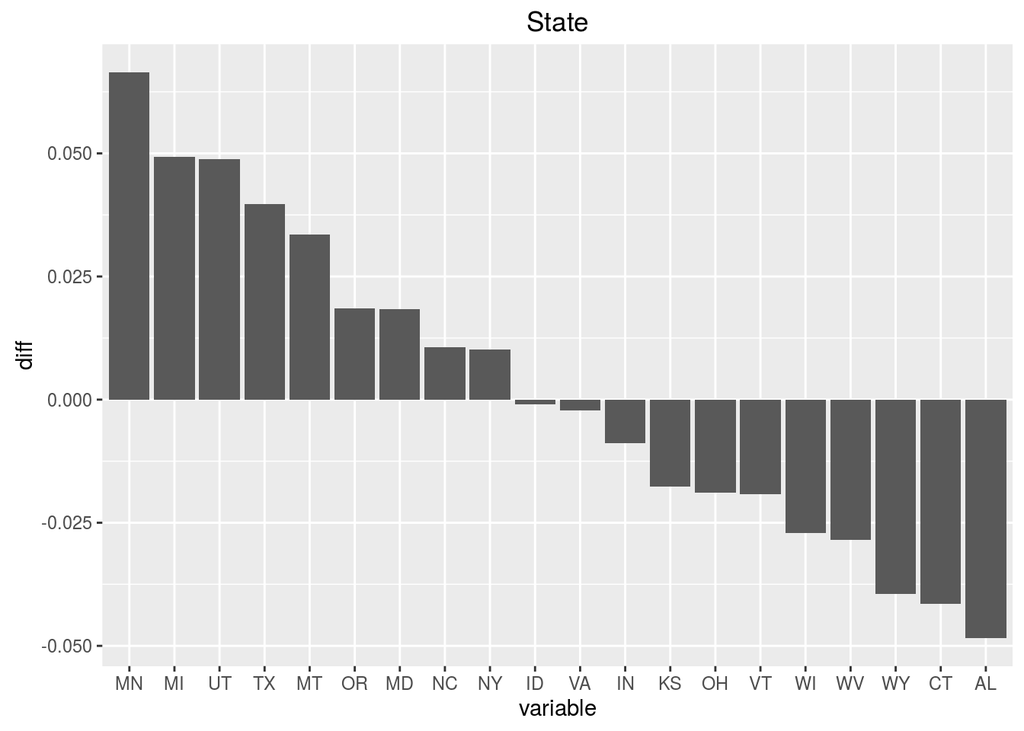

```r
source("https://raw.githubusercontent.com/a-ghorbani/notebooks/master/H2O/examples/churn/partialDependencePlot.R")

cols <- var.imp[1:5]
pdps <- lapply(cols, function(x) partialDependencePlot(bestModel, x, data_frame) )

lapply(1:length(cols), function(x){
  x_ <- melt(pdps[[x]])
  colnames(x_) <- c("variable", "diff")
  if(class(x_$variable) == 'factor'){
    # order based on diff
    x_ <- within(x_, variable <- factor(variable, levels=variable[order(-diff)]))
    p <- ggplot(data = x_, aes(x = variable, y = diff)) +
      geom_bar(stat="identity" )
  }else{
    p <- ggplot(data = x_, aes(x = variable, y = diff)) +
      geom_line()
  }
  p + ggtitle(cols[x])
})
```

The above plots show only impact of single variable if others are kept constant. But in many cases, specially if there is interaction between variables, we are interested to know the impact on changing two or more variables. For this also we can use `partialDependencePlot.R`. As an example in the following we can see the impact of “Day Charge” for each state, and also on average. It can be seen that there are quite variances among different states.

```r
cols <- c("State", "Day Charge")
pdp1 <- partialDependencePlot(bestModel, cols, data_frame)

pdp2 <- partialDependencePlot(bestModel, "Day Charge", data_frame)

pdp1 <- melt(pdp1)
pdp2 <- melt(pdp2)
pdp2$State <- "AVG"

colnames(pdp1) <- c("State", "Day.Charge", "diff")
colnames(pdp2) <- c("Day.Charge", "diff", "State")
```

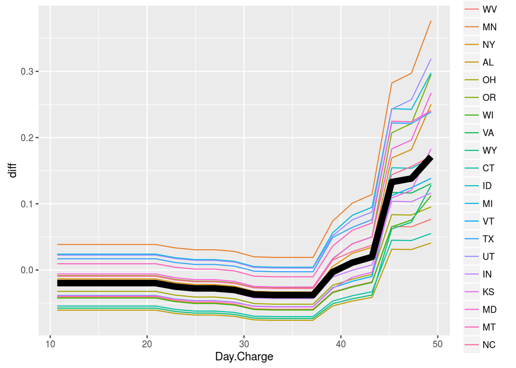

```r
ggplot(data = pdp1,
       aes(x     = Day.Charge,
           y     = diff,
           color = State,
           group = State)) +
  geom_line() +
  geom_line(data = pdp2, size=3, color='black')
```

## A Simplified Single Decision Tree

Alright, so far we did quite a lot. We found important variables, impact of changing each variables on the outcome. However, we would like to have the big picture. A high level insight about the model.

For that, we can build a single decision tree. But we already know that if we use single decision tree to build the model it can’t accurate.

In order to improve the accuracy we use a single decision tree to approximate the GBM model. So we train a decision tree with that data but the target variable is replaced by the prediction of GBM. The premise behind this, according to what a friend of me Armin told once, is that using predictions of GBM (or other complex models) kind of removes the noise from the data, and makes it easier for less complex model (like single decision trees) to train.

Additionally, here, we use only rows that are predicted with high confidence, i.e. probabilities close to 0 and 1.

```r
denoise.h2o.df <- function(model, data_frame, destination_frame, lower.q=0.2, higher.q=0.8){
  # Removes the data points that cannot be classified significantly.
  # That means the data points for which the prediction is far away from 0 and 1,
  # like those close to 0.5
  #
  # Args:
  #   model: A H2O model.
  #   data_frame: A H2O data frame.
  #   destination_frame: ID for the result frame.
  #   lower.q: The lower quantile, from which the data points will be ignored.
  #   higher.q: The higher quantile, to which the data points will be ignored.
  #
  # Returns:
  #   The resulting H2O data frame.

  pred   <- h2o.predict(model, data_frame)
  predCol <- names(pred)[3]
  quant  <- h2o.quantile(pred[,predCol], probs = c(lower.q, higher.q))
  lower  <- min(quant)
  higher <- max(quant)
  data_pred <- h2o.cbind(data_frame, pred)
  data_denoised <- data_pred[
    data_pred[,predCol] < lower |
      data_pred[,predCol] > higher,]
  data_denoised <- h2o.assign(data_denoised, destination_frame)
  return(data_denoised)
}

denoised_train_df <-
  denoise.h2o.df(
    model             = bestModel,
    data_frame        = train_frame,
    destination_frame = "denoised_train_frame",
    lower.q           = 0.1,
    higher.q          = 0.9)

denoised_test_df <-
  denoise.h2o.df(
    model             = bestModel,
    data_frame        = test_frame,
    destination_frame = "denoised_test_frame",
    lower.q           = 0.1,
    higher.q          = 0.9)
```

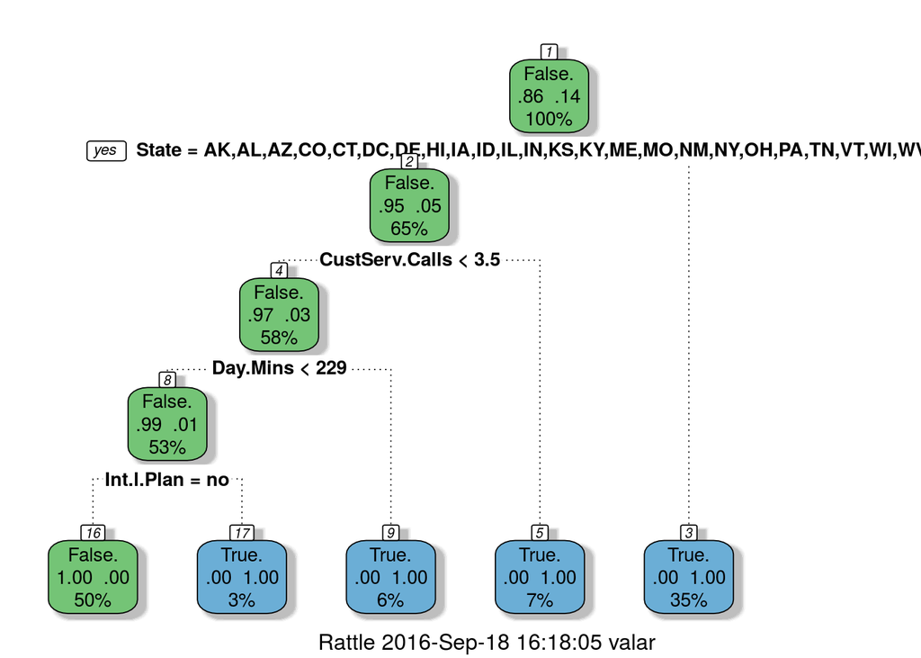

```r
train_df <- as.data.frame(denoised_train_df)
test_df  <- as.data.frame(test_frame)
test_df1 <- as.data.frame(denoised_test_df)

# Ignore the columns that is not in used in training
tmp.df <- train_df[, -which(names(train_df)  %in% c("Churn.","False.","True.", "Phone" ))]
colnames(tmp.df)[colnames(tmp.df) == "predict"] <- "Churn."

counts <- as.data.frame(h2o.table(data_frame[,"Churn?"]))

priorDist <- counts$Count[1] / sum(counts$Count)
priorDist <- c(priorDist, 1 - priorDist)

tree <- rpart(
    formula  = Churn. ~ .,
    data     = tmp.df,
    maxdepth = 5,
    cp       = 0.02,
    parms    = list(prior = priorDist,
                    split = "information"))

fancyRpartPlot(tree)
```

```r
id <- which(!(test_df$State %in% levels(train_df$State)))
test_df$State[id] <- NA

Pred1 <- predict(tree, test_df)
test_df$Prediction1 <- Pred1[,"True."]
ROC1 <- roc(test_df$Churn., test_df$Prediction1)
ROC1$auc
```

```
## Area under the curve: 0.6671
```

# Conclusion

The purpose of this article was to show how we can go through a data science task of a classification problem using H2O, one of the most powerful open source library for big data. It’s speed and performance allows to accomplish analytics tasks for huge amount of data that is not so easy otherwise, like:

- building **many** models,
- parameter tuning,
- variable importance at customer level,
- (low dimensional) partial dependence analysis.

For example note that for a two dimensional partial dependence analysis with only 20 points for each dimension we need to perform prediction over all data set 400 times (i.e. 20*20).

# Disclaimer

I am not affiliated, associated, authorized, endorsed by, or in any way officially connected with h2o.ai. I just enjoy using this product.